# Week4 - Assignment

M. Onimus

9/27/2020

# Read in Data

```r
school <- read_sav("assignments/BasicTests_School.sav") %>%
  mutate(School = as.factor(School))
```

# Question 1

Chichi and David are still working on their study of what children are eating for lunch at school. In the BasicTests School.sav file are 8 random samples of meals from 3 schools (hence 24 observations total). The data represents fat content in grams from meals served at the schools. The two are interested in whether there is a difference in fat content of the lunches between schools. Please test that hypothesis using an ANOVA.

## Question/Answer 1a

What are the null and alternative hypotheses?

**H<sub>0</sub>:** $\mu_1=\mu_2, \mu_1=\mu_3, \mu_2=\mu_3$

**H<sub>A</sub>:** $\mu_i \neq \mu_m$ for some $i\neq m$

## Question/Answer 1b

What is the average fat content in the lunches of each of the schools?

```r
sumSchool <- school %>%
  group_by(School) %>%
  summarize(mean = mean(FatContent))

sumSchool %>%
  gt() %>%
  tab_header(
    title = "Means of FatContent by School"
  )
```

Means of FatContent by School

| School | mean |
| --- | --- |
| 1 | 138.125 |
| 2 | 135.000 |
| 3 | 141.000 |

**The mean fat content of school 1 is 138.125, school 2 is 135, and school 3 is 141.**

## Question/Answer 1c

What is the test statistic? What are the degrees of freedom?

```r
a1 <- aov(FatContent ~ School, data = school)

aSum <- summary(a1) # it is tough to pull apart the anova model, easier with the summary


pander::pander(anova(a1))
```

Analysis of Variance Table

|  | Df | Sum Sq | Mean Sq | F value | Pr(>F) |
| --- | --- | --- | --- | --- | --- |
| **School** | 2 | 144.1 | 72.04 | 0.8354 | 0.4476 |
| **Residuals** | 21 | 1811 | 86.23 | NA | NA |

**The F-value test statistics is 0.8354387 and the degrees of freedom are 2.**

## Question/Answer 1d

What is the p-value associated with that test statistic?

**The associated $p$-value with the test statistic is 0.4475949.**

## Question/Answer 1e

What can you say about the model assumption of homogeneous variances between groups? Please include any relevant plots or descriptive/inferential statistics as appropriate to support your discussion.

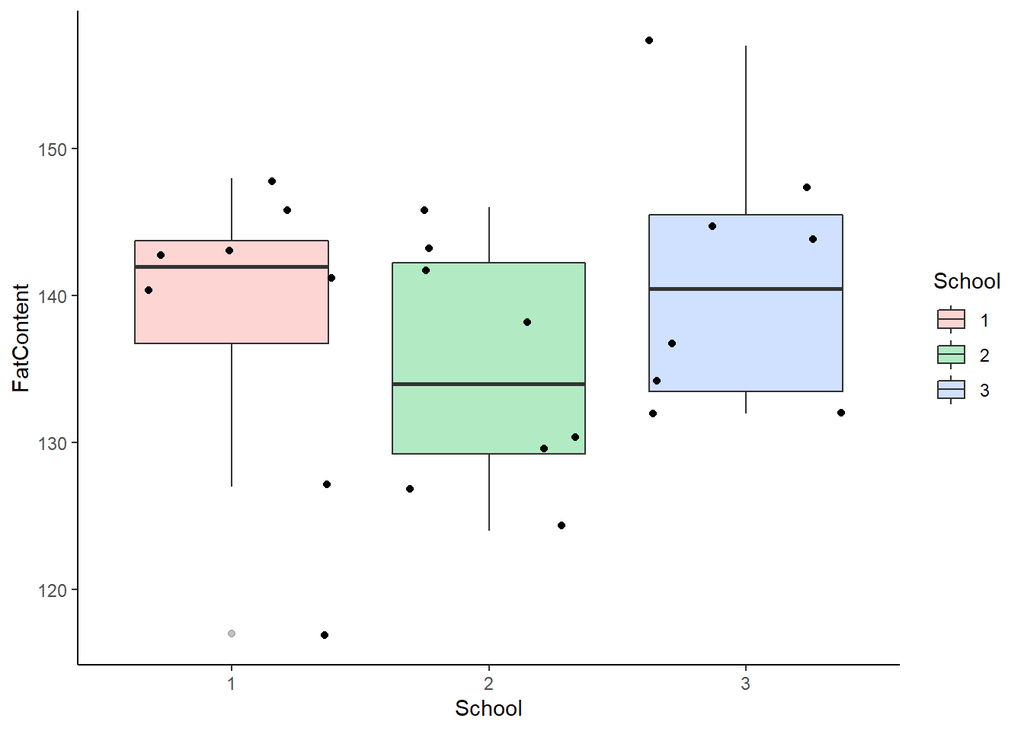

```r
levene <- levene_test(FatContent ~ School, data = school)

ggplot(school, aes(x = School, y = FatContent)) +
  geom_boxplot(aes(fill = School), alpha = 0.3) +
  geom_jitter() +
  theme_classic()
```

**The Levene F-value test statistic from the Levene test was 0.0109091 with a corresponding $p$-value of 0.9891558. Indicating we can assume consistent variance. This is also demostrated by the boxplot showing the distrubtion for each school is approximately the same.**

**NOTE: these results are different from what is produced in SAS and I am not sure why yet.**

## Question/Answer 1f

Are post-hoc tests appropriate? If so, please report on which schools differ in fat content, using a Bonferroni correction.

```r
pwt <- school %>%
  pairwise_t_test(FatContent ~ School, p.adjust.method = "bonferroni")

pwt
```

```
## # A tibble: 3 x 9
##   .y.        group1 group2    n1    n2     p p.signif p.adj p.adj.signif
## * <chr>      <chr>  <chr>  <int> <int> <dbl> <chr>    <dbl> <chr>
## 1 FatContent 1      2          8     8 0.508 ns       1     ns
## 2 FatContent 1      3          8     8 0.542 ns       1     ns
## 3 FatContent 2      3          8     8 0.21  ns       0.631 ns
```

**The $p$-value of 0.4475949 from the ANOVA indicated that no group was significantly different; an post-hoc analysis may not be needed as we have answered the main question already. As a practice, I have completed a pairwise t test regardless. As the ANOVA indicated, there is no significant differences between any school in terms of fat content.**

## Question/Answer 1g

Write up your interpretation of the results of your analysis.

**In this study of what children are eating for lunch at school, we observed no significant differences between the fat content of 3 different schools (F-value = 0.8354387, $p$-value of 0.4475949).**